# MTH 209 Data Manipulation and Management

Lesson 10: R Markdown Presentations

Ying-Ju Tessa Chen  
ychen4@udayton.edu  
University of Dayton

# Overview

In this session, we will introduce

1. Rmarkdown Presentations
2. Flex Dashboard

# Rmarkdown Presentations - 1

In order to create a Rmarkdown presentation, we click File and then find New File and then R markdown … There are four options:

- Html (ioslides)

This format allows us to create a slide show and the slides could be broken up into sections by using the heading tags # and ##. If a header is not needed, a new slide could be created using a horizontal rule (- - -).

- Html (Slidy)

Similar to ioslides, this format allows to create a slide show broken up into sections by using the heading tag ##. If a header is not needed, a new slide could be created using a horizontal rule (- - -). A Slidy presentation gives a table of content while An ioslides presentation doesn’t.

- PDF (beamer)

This format allows to create a beamer presenation (LaTex). The slides could be broken up into sections by using the heading tags # and ##. If a header is not needed, a new slide could be created using a horizontal rule (- - -).

- PowerPoint

# Rmarkdown Presentations - 2

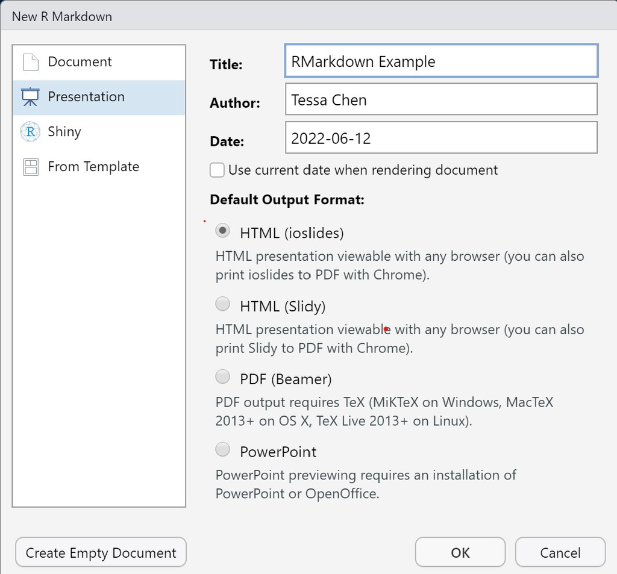

Creating a Rmarkdown Presentation

# Rmarkdown Presentations - 3

In the following, we show an example of the header of a Rmarkdown file.

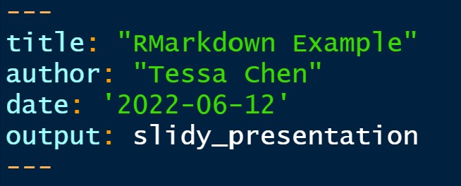

We can use the output option to manipulate which presentation we would like to have.

- output: ioslides_presentation
- output: slidy_presentation
- output: beamer_presentation
- output: powerpoint_presentation

To render an R Markdown document into its final output format, we can click the Knit button to render the document in RStudio and RStudio will show a preview of it.

The further settings for presentations could be found at [R Markdown: The Definitive Guide](https://bookdown.org/yihui/rmarkdown/presentations.html)

# xaringan Presentation

A easy way to start creating a xaringan presentation is to use the R markdown template with Ninja Presentation or Ninja Themed Presentation.

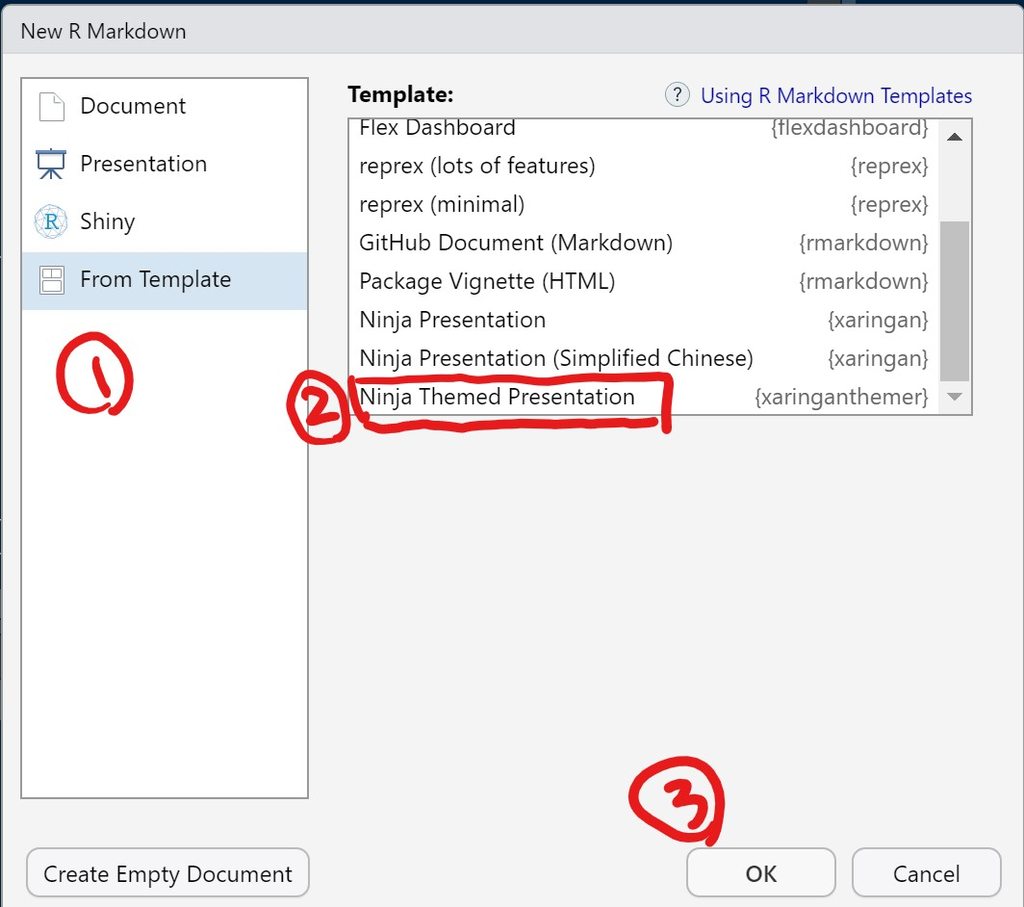

Creating a Rmarkdown Presentation

A comprehensive tutorial regarding xaringan presentation could be found at [xaringan Presentation](https://bookdown.org/yihui/rmarkdown/xaringan.html)

# Flex Dashboard

A easy way to start creating a Flex dashboard is to use the R markdown template with Flex Dashboard.

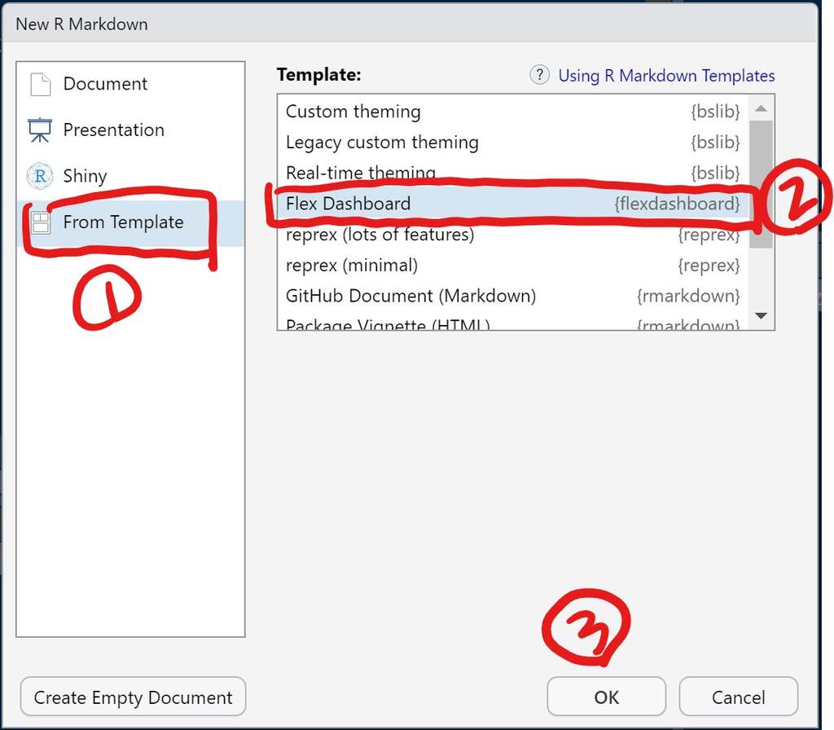

Creating a Flex Dashboard

- We can use # to create multiple pages.
- We can use orientation in the output options to specify the layout to be columns or rows.

A comprehensive tutorial regarding Flex Dashboard could be found at [flexdashboard](https://pkgs.rstudio.com/flexdashboard/)

# README

You can utilize the following single character keyboard shortcuts to enable alternate display modes (Xie, Allaire, and Grolemund (2018)):

- A: Switches show of current versus all slides (helpful for printing all pages)
- B: Make fonts large
- c: Show table of contents
- S: Make fonts smaller

Xie, Yihui, Joseph J Allaire, and Garrett Grolemund. 2018. *R Markdown: The Definitive Guide*. CRC Press.